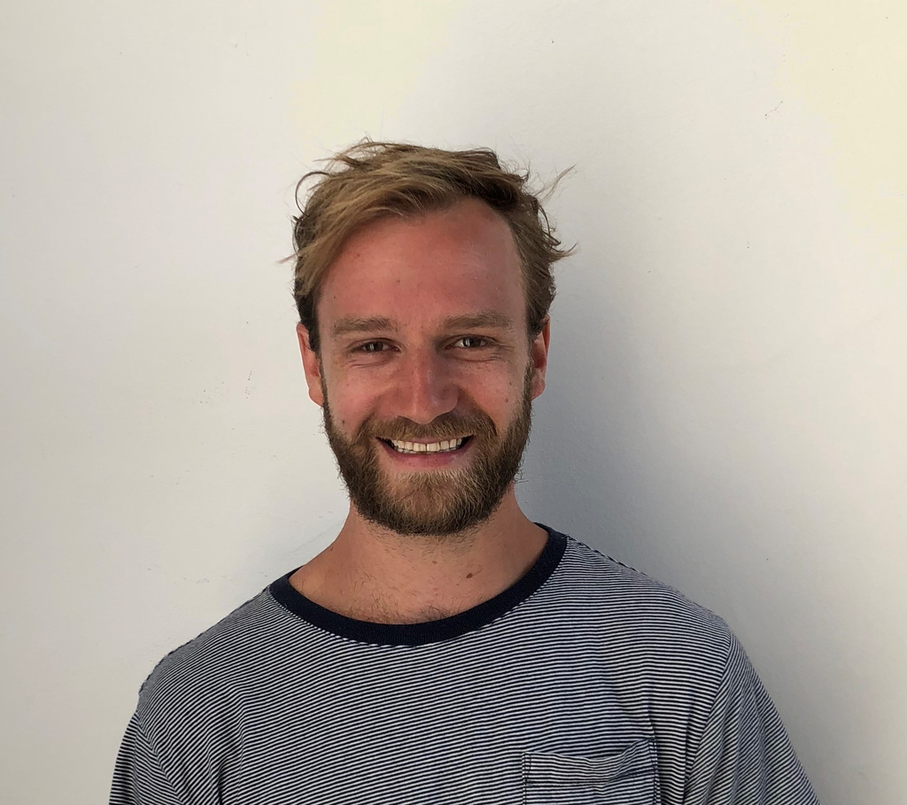

# Dr Loren Kock

##### My work

I am a researcher in the applied epidemiology and behavioural science of addiction. My work uses a systems lens, recognising that changing behavior to minimise the harms from addiction involves multiple factors at the individual, community and population level. I conduct policy-oriented research to inform improvements in the health of populations and priority groups in society that experience a disproportionate level of harm from substance use.

##### Key Skills

- **Data analysis & visualisation**
  - Statistical analysis of population survey data and randomized controlled trial data
  - Data wrangling and statistical programming using R
  - Qualitative data analysis
- **Communication**
  - Oral presentation of research to academic and policy-focused stakeholders
  - Lecture to MSc and BSc programmes in epidemiology, behaviour change, addiction and public health
  - Report writing and publication of research in academic journals
  - Communication of research to public audiences

##### Experience

- Post-doctoral Research Fellow in the [Vermont Centre on Behavior and Health](http://www.med.uvm.edu/behaviorandhealth/home) at the University of Vermont. 2022-Present
- Consultant with [United Health Futures](https://www.uhf.ch) on WHO funded reports for country governments related Tobacco and Alcohol Policy. 2022
- Post-doctoral Research Fellow in the [Tobacco and Alcohol Research Group](https://www.ucl.ac.uk/epidemiology-health-care/research/behavioural-science-and-health/research/ucl-tobacco-alcohol-research-group-utarg) at University College London. 2020-2022
- Analyst at [My Clinical Outcomes](https://www.myclinicaloutcomes.com/). 2015-2017

##### Education

[**PhD**](https://discovery.ucl.ac.uk/id/eprint/10108576/), Epidemiology and Behavioural Science, [UCL](https://www.ucl.ac.uk/epidemiology-health-care/) (2020)  
**MSc**, Global Health, [UCL](https://www.ucl.ac.uk/global-health/global-health-and-development-msc) (2016)  
**BSc**, Biomedical Science, [University of Edinburgh](https://www.ed.ac.uk/biomedical-sciences) (2015)

##### Scientific and Academic Citizenship

**Society for Research on Nicotine and Tobacco** - Co-chair of Policy and Regulatory Science Network Education Sub-committee and member of Advisory Committee  
**Journal of Nicotine and Tobacco Research** - Associate Editor  
**Royal College of Physicians** - Author of chapter on vaping in priority socioeconomic groups in 2024 [RCP report](https://www.rcplondon.ac.uk/projects/outputs/e-cigarettes-and-harm-reduction-evidence-review)

##### Select Recent Publications

- [Commentary on Ussher et al.: Duration and magnitude of postpartum financial incentives for the maintenance of cigarette smoking abstinence](https://onlinelibrary.wiley.com/doi/10.1111/add.16580) (2024) *Addiction*
- [Brief interventions for smoking and alcohol associated with the COVID-19 pandemic: a population survey in England](https://link.springer.com/article/10.1186/s12889-023-17559-7) (2024) *BMC Public Health*
- [Intersection of gambling with smoking and alcohol use in Great Britain: a cross-sectional survey in October 2022](https://bmjopen.bmj.com/content/14/4/e079633.abstract) (2024) *BMJ Open*
- [Prevalence of Psychosocial Issues Among Pregnant Women Who Do and Do Not Use Illicit Substances](https://psycnet.apa.org/doiLanding?doi=10.1037%2Fadb0000952) (2023) *Psychology of Addictive Behaviors*
- [Contingency management interventions for abstinence from cigarette smoking in pregnancy and postpartum: A systematic review and meta-analysis](https://www.sciencedirect.com/science/article/abs/pii/S0091743523002347) (2023) *Preventive Medicine*
- [Association of psychological distress with smoking cessation, duration of abstinence from smoking, and use of non-combustible nicotine-containing products: A cross-sectional population survey in Great Britain](https://www.sciencedirect.com/science/article/pii/S0306460322003367) (2023) *Addictive Behaviors*
- [Inequalities in Smoking and Quitting-Related Outcomes Among Adults With and Without Children in the Household 2013–2019: A Population Survey in England](https://academic.oup.com/ntr/article/24/5/690/6387990) (2022) *Journal of Nicotine and Tobacco Research*
- [E-cigarettes to Augment Stop Smoking In-person Support and Treatment With Varenicline (E-ASSIST): A Pragmatic Randomized Controlled Trial](https://academic.oup.com/ntr/advance-article/doi/10.1093/ntr/ntac149/6615413) (2022) *Journal of Nicotine and Tobacco Research*
- [Individual-level behavioural smoking cessation interventions tailored for disadvantaged socioeconomic position: a systematic review and meta-regression](https://www.sciencedirect.com/science/article/pii/S2468266719302208) (2019) *The Lancet Public Health*